# Data Access with Zipline

Zipline is the algorithmic trading library that used to power the now-defunct Quantopian backtesting and live-trading platform. It is also available offline to develop a strategy using a limited number of free data bundles that can be ingested and used to test the performance of trading ideas.

## Zipline installation

> This notebook requires the `conda` environment `backtest`. Please see the installation instructions for running the latest Docker image or alternative ways to set up your environment.

There is much more information about Zipline in Chapter 8.

## Imports & Settings

```python
%matplotlib inline
import pandas as pd
```

```python
%load_ext zipline
```

## zipline Demo

### Ingest Data

Get QUANDL API key and follow instructions to download zipline bundles [here](https://zipline.ml4trading.io/bundles.html). This boils down to running:

```python
# !zipline ingest
```

See `zipline` [docs](https://zipline.ml4trading.io/bundles.html) on the download and management of data bundles used to simulate backtests.

The following commandline instruction lists the available bundles (store per default in `~/.zipline`.

```python
# !zipline bundles
```

### Data access using zipline

The following code illustrates how zipline permits us to access daily stock data for a range of companies. You can run zipline scripts in the Jupyter Notebook using the magic function of the same name.

First, you need to initialize the context with the desired security symbols. We'll also use a counter variable. Then zipline calls handle_data, where we use the `data.history()` method to look back a single period and append the data for the last day to a .csv file:

```python
%%zipline --start 2010-1-1 --end 2018-1-1 --data-frequency daily --no-benchmark
from zipline.api import order_target, record, symbol
import pandas as pd

def initialize(context):
    context.i = 0
    context.assets = [symbol('FB'), symbol('GOOG'), symbol('AMZN')]

def handle_data(context, data):
    df = data.history(context.assets, fields=['price', 'volume'], bar_count=1, frequency="1d")
    df = df.reset_index()

    if context.i == 0:
        df.columns = ['date', 'asset', 'price', 'volume']
        df.to_csv('stock_data.csv', index=False)
    else:
        df.to_csv('stock_data.csv', index=False, mode='a', header=None)
    context.i += 1
```

|  | algo_volatility | algorithm_period_return | alpha | benchmark_period_return | benchmark_volatility | beta | capital_used | ending_cash | ending_exposure | ending_value | ... | short_exposure | short_value | shorts_count | sortino | starting_cash | starting_exposure | starting_value | trading_days | transactions | treasury_period_return |
| --- | --- | --- | --- | --- | --- | --- | --- | --- | --- | --- | --- | --- | --- | --- | --- | --- | --- | --- | --- | --- | --- |
| 2010-01-04 21:00:00+00:00 | NaN | 0.0 | NaN | 0.002012 | NaN | NaN | 0.0 | 10000000.0 | 0.0 | 0.0 | ... | 0.0 | 0.0 | 0 | None | 10000000.0 | 0.0 | 0.0 | 1 | [] | 0.0 |
| 2010-01-05 21:00:00+00:00 | 0.0 | 0.0 | NaN | 0.004029 | 0.000000 | NaN | 0.0 | 10000000.0 | 0.0 | 0.0 | ... | 0.0 | 0.0 | 0 | None | 10000000.0 | 0.0 | 0.0 | 2 | [] | 0.0 |
| 2010-01-06 21:00:00+00:00 | 0.0 | 0.0 | NaN | 0.006049 | 0.000000 | NaN | 0.0 | 10000000.0 | 0.0 | 0.0 | ... | 0.0 | 0.0 | 0 | None | 10000000.0 | 0.0 | 0.0 | 3 | [] | 0.0 |
| 2010-01-07 21:00:00+00:00 | 0.0 | 0.0 | NaN | 0.008073 | 0.000000 | NaN | 0.0 | 10000000.0 | 0.0 | 0.0 | ... | 0.0 | 0.0 | 0 | None | 10000000.0 | 0.0 | 0.0 | 4 | [] | 0.0 |
| 2010-01-08 21:00:00+00:00 | 0.0 | 0.0 | NaN | 0.010102 | 0.000000 | NaN | 0.0 | 10000000.0 | 0.0 | 0.0 | ... | 0.0 | 0.0 | 0 | None | 10000000.0 | 0.0 | 0.0 | 5 | [] | 0.0 |
| 2010-01-11 21:00:00+00:00 | 0.0 | 0.0 | NaN | 0.012134 | 0.000000 | NaN | 0.0 | 10000000.0 | 0.0 | 0.0 | ... | 0.0 | 0.0 | 0 | None | 10000000.0 | 0.0 | 0.0 | 6 | [] | 0.0 |
| 2010-01-12 21:00:00+00:00 | 0.0 | 0.0 | NaN | 0.014171 | 0.000000 | NaN | 0.0 | 10000000.0 | 0.0 | 0.0 | ... | 0.0 | 0.0 | 0 | None | 10000000.0 | 0.0 | 0.0 | 7 | [] | 0.0 |
| 2010-01-13 21:00:00+00:00 | 0.0 | 0.0 | NaN | 0.016212 | 0.000000 | NaN | 0.0 | 10000000.0 | 0.0 | 0.0 | ... | 0.0 | 0.0 | 0 | None | 10000000.0 | 0.0 | 0.0 | 8 | [] | 0.0 |
| 2010-01-14 21:00:00+00:00 | 0.0 | 0.0 | NaN | 0.018257 | 0.000000 | NaN | 0.0 | 10000000.0 | 0.0 | 0.0 | ... | 0.0 | 0.0 | 0 | None | 10000000.0 | 0.0 | 0.0 | 9 | [] | 0.0 |
| 2010-01-15 21:00:00+00:00 | 0.0 | 0.0 | NaN | 0.020306 | 0.000000 | NaN | 0.0 | 10000000.0 | 0.0 | 0.0 | ... | 0.0 | 0.0 | 0 | None | 10000000.0 | 0.0 | 0.0 | 10 | [] | 0.0 |
| 2010-01-19 21:00:00+00:00 | 0.0 | 0.0 | NaN | 0.022359 | 0.000000 | NaN | 0.0 | 10000000.0 | 0.0 | 0.0 | ... | 0.0 | 0.0 | 0 | None | 10000000.0 | 0.0 | 0.0 | 11 | [] | 0.0 |
| 2010-01-20 21:00:00+00:00 | 0.0 | 0.0 | NaN | 0.024416 | 0.000000 | NaN | 0.0 | 10000000.0 | 0.0 | 0.0 | ... | 0.0 | 0.0 | 0 | None | 10000000.0 | 0.0 | 0.0 | 12 | [] | 0.0 |
| 2010-01-21 21:00:00+00:00 | 0.0 | 0.0 | NaN | 0.026478 | 0.000000 | NaN | 0.0 | 10000000.0 | 0.0 | 0.0 | ... | 0.0 | 0.0 | 0 | None | 10000000.0 | 0.0 | 0.0 | 13 | [] | 0.0 |
| 2010-01-22 21:00:00+00:00 | 0.0 | 0.0 | NaN | 0.028543 | 0.000000 | NaN | 0.0 | 10000000.0 | 0.0 | 0.0 | ... | 0.0 | 0.0 | 0 | None | 10000000.0 | 0.0 | 0.0 | 14 | [] | 0.0 |
| 2010-01-25 21:00:00+00:00 | 0.0 | 0.0 | NaN | 0.030613 | 0.000000 | NaN | 0.0 | 10000000.0 | 0.0 | 0.0 | ... | 0.0 | 0.0 | 0 | None | 10000000.0 | 0.0 | 0.0 | 15 | [] | 0.0 |
| 2010-01-26 21:00:00+00:00 | 0.0 | 0.0 | NaN | 0.032687 | 0.000000 | NaN | 0.0 | 10000000.0 | 0.0 | 0.0 | ... | 0.0 | 0.0 | 0 | None | 10000000.0 | 0.0 | 0.0 | 16 | [] | 0.0 |
| 2010-01-27 21:00:00+00:00 | 0.0 | 0.0 | NaN | 0.034765 | 0.000000 | NaN | 0.0 | 10000000.0 | 0.0 | 0.0 | ... | 0.0 | 0.0 | 0 | None | 10000000.0 | 0.0 | 0.0 | 17 | [] | 0.0 |
| 2010-01-28 21:00:00+00:00 | 0.0 | 0.0 | NaN | 0.036847 | 0.000000 | NaN | 0.0 | 10000000.0 | 0.0 | 0.0 | ... | 0.0 | 0.0 | 0 | None | 10000000.0 | 0.0 | 0.0 | 18 | [] | 0.0 |
| 2010-01-29 21:00:00+00:00 | 0.0 | 0.0 | NaN | 0.038933 | 0.000000 | NaN | 0.0 | 10000000.0 | 0.0 | 0.0 | ... | 0.0 | 0.0 | 0 | None | 10000000.0 | 0.0 | 0.0 | 19 | [] | 0.0 |
| 2010-02-01 21:00:00+00:00 | 0.0 | 0.0 | NaN | 0.041024 | 0.000000 | NaN | 0.0 | 10000000.0 | 0.0 | 0.0 | ... | 0.0 | 0.0 | 0 | None | 10000000.0 | 0.0 | 0.0 | 20 | [] | 0.0 |
| 2010-02-02 21:00:00+00:00 | 0.0 | 0.0 | NaN | 0.043119 | 0.000000 | NaN | 0.0 | 10000000.0 | 0.0 | 0.0 | ... | 0.0 | 0.0 | 0 | None | 10000000.0 | 0.0 | 0.0 | 21 | [] | 0.0 |
| 2010-02-03 21:00:00+00:00 | 0.0 | 0.0 | NaN | 0.045218 | 0.000000 | NaN | 0.0 | 10000000.0 | 0.0 | 0.0 | ... | 0.0 | 0.0 | 0 | None | 10000000.0 | 0.0 | 0.0 | 22 | [] | 0.0 |
| 2010-02-04 21:00:00+00:00 | 0.0 | 0.0 | NaN | 0.047321 | 0.000000 | NaN | 0.0 | 10000000.0 | 0.0 | 0.0 | ... | 0.0 | 0.0 | 0 | None | 10000000.0 | 0.0 | 0.0 | 23 | [] | 0.0 |
| 2010-02-05 21:00:00+00:00 | 0.0 | 0.0 | NaN | 0.049429 | 0.000000 | NaN | 0.0 | 10000000.0 | 0.0 | 0.0 | ... | 0.0 | 0.0 | 0 | None | 10000000.0 | 0.0 | 0.0 | 24 | [] | 0.0 |
| 2010-02-08 21:00:00+00:00 | 0.0 | 0.0 | NaN | 0.051540 | 0.000000 | NaN | 0.0 | 10000000.0 | 0.0 | 0.0 | ... | 0.0 | 0.0 | 0 | None | 10000000.0 | 0.0 | 0.0 | 25 | [] | 0.0 |
| 2010-02-09 21:00:00+00:00 | 0.0 | 0.0 | NaN | 0.053656 | 0.000000 | NaN | 0.0 | 10000000.0 | 0.0 | 0.0 | ... | 0.0 | 0.0 | 0 | None | 10000000.0 | 0.0 | 0.0 | 26 | [] | 0.0 |
| 2010-02-10 21:00:00+00:00 | 0.0 | 0.0 | NaN | 0.055776 | 0.000000 | NaN | 0.0 | 10000000.0 | 0.0 | 0.0 | ... | 0.0 | 0.0 | 0 | None | 10000000.0 | 0.0 | 0.0 | 27 | [] | 0.0 |
| 2010-02-11 21:00:00+00:00 | 0.0 | 0.0 | NaN | 0.057901 | 0.000000 | NaN | 0.0 | 10000000.0 | 0.0 | 0.0 | ... | 0.0 | 0.0 | 0 | None | 10000000.0 | 0.0 | 0.0 | 28 | [] | 0.0 |
| 2010-02-12 21:00:00+00:00 | 0.0 | 0.0 | NaN | 0.060030 | 0.000000 | NaN | 0.0 | 10000000.0 | 0.0 | 0.0 | ... | 0.0 | 0.0 | 0 | None | 10000000.0 | 0.0 | 0.0 | 29 | [] | 0.0 |
| 2010-02-16 21:00:00+00:00 | 0.0 | 0.0 | NaN | 0.062163 | 0.000000 | NaN | 0.0 | 10000000.0 | 0.0 | 0.0 | ... | 0.0 | 0.0 | 0 | None | 10000000.0 | 0.0 | 0.0 | 30 | [] | 0.0 |
| ... | ... | ... | ... | ... | ... | ... | ... | ... | ... | ... | ... | ... | ... | ... | ... | ... | ... | ... | ... | ... | ... |
| 2017-11-16 21:00:00+00:00 | 0.0 | 0.0 | 0.0 | 25.150448 | 0.052440 | 0.0 | 0.0 | 10000000.0 | 0.0 | 0.0 | ... | 0.0 | 0.0 | 0 | None | 10000000.0 | 0.0 | 0.0 | 1984 | [] | 0.0 |
| 2017-11-17 21:00:00+00:00 | 0.0 | 0.0 | 0.0 | 25.081776 | 0.052449 | 0.0 | 0.0 | 10000000.0 | 0.0 | 0.0 | ... | 0.0 | 0.0 | 0 | None | 10000000.0 | 0.0 | 0.0 | 1985 | [] | 0.0 |
| 2017-11-20 21:00:00+00:00 | 0.0 | 0.0 | 0.0 | 25.115050 | 0.052435 | 0.0 | 0.0 | 10000000.0 | 0.0 | 0.0 | ... | 0.0 | 0.0 | 0 | None | 10000000.0 | 0.0 | 0.0 | 1986 | [] | 0.0 |
| 2017-11-21 21:00:00+00:00 | 0.0 | 0.0 | 0.0 | 25.285871 | 0.052451 | 0.0 | 0.0 | 10000000.0 | 0.0 | 0.0 | ... | 0.0 | 0.0 | 0 | None | 10000000.0 | 0.0 | 0.0 | 1987 | [] | 0.0 |
| 2017-11-22 21:00:00+00:00 | 0.0 | 0.0 | 0.0 | 25.266149 | 0.052445 | 0.0 | 0.0 | 10000000.0 | 0.0 | 0.0 | ... | 0.0 | 0.0 | 0 | None | 10000000.0 | 0.0 | 0.0 | 1988 | [] | 0.0 |
| 2017-11-24 18:00:00+00:00 | 0.0 | 0.0 | 0.0 | 25.320156 | 0.052432 | 0.0 | 0.0 | 10000000.0 | 0.0 | 0.0 | ... | 0.0 | 0.0 | 0 | None | 10000000.0 | 0.0 | 0.0 | 1989 | [] | 0.0 |
| 2017-11-27 21:00:00+00:00 | 0.0 | 0.0 | 0.0 | 25.310043 | 0.052424 | 0.0 | 0.0 | 10000000.0 | 0.0 | 0.0 | ... | 0.0 | 0.0 | 0 | None | 10000000.0 | 0.0 | 0.0 | 1990 | [] | 0.0 |
| 2017-11-28 21:00:00+00:00 | 0.0 | 0.0 | 0.0 | 25.569156 | 0.052492 | 0.0 | 0.0 | 10000000.0 | 0.0 | 0.0 | ... | 0.0 | 0.0 | 0 | None | 10000000.0 | 0.0 | 0.0 | 1991 | [] | 0.0 |
| 2017-11-29 21:00:00+00:00 | 0.0 | 0.0 | 0.0 | 25.559346 | 0.052483 | 0.0 | 0.0 | 10000000.0 | 0.0 | 0.0 | ... | 0.0 | 0.0 | 0 | None | 10000000.0 | 0.0 | 0.0 | 1992 | [] | 0.0 |
| 2017-11-30 21:00:00+00:00 | 0.0 | 0.0 | 0.0 | 25.776892 | 0.052522 | 0.0 | 0.0 | 10000000.0 | 0.0 | 0.0 | ... | 0.0 | 0.0 | 0 | None | 10000000.0 | 0.0 | 0.0 | 1993 | [] | 0.0 |
| 2017-12-01 21:00:00+00:00 | 0.0 | 0.0 | 0.0 | 25.722683 | 0.052525 | 0.0 | 0.0 | 10000000.0 | 0.0 | 0.0 | ... | 0.0 | 0.0 | 0 | None | 10000000.0 | 0.0 | 0.0 | 1994 | [] | 0.0 |
| 2017-12-04 21:00:00+00:00 | 0.0 | 0.0 | 0.0 | 25.694566 | 0.052521 | 0.0 | 0.0 | 10000000.0 | 0.0 | 0.0 | ... | 0.0 | 0.0 | 0 | None | 10000000.0 | 0.0 | 0.0 | 1995 | [] | 0.0 |
| 2017-12-05 21:00:00+00:00 | 0.0 | 0.0 | 0.0 | 25.594744 | 0.052542 | 0.0 | 0.0 | 10000000.0 | 0.0 | 0.0 | ... | 0.0 | 0.0 | 0 | None | 10000000.0 | 0.0 | 0.0 | 1996 | [] | 0.0 |
| 2017-12-06 21:00:00+00:00 | 0.0 | 0.0 | 0.0 | 25.591710 | 0.052533 | 0.0 | 0.0 | 10000000.0 | 0.0 | 0.0 | ... | 0.0 | 0.0 | 0 | None | 10000000.0 | 0.0 | 0.0 | 1997 | [] | 0.0 |
| 2017-12-07 21:00:00+00:00 | 0.0 | 0.0 | 0.0 | 25.669687 | 0.052522 | 0.0 | 0.0 | 10000000.0 | 0.0 | 0.0 | ... | 0.0 | 0.0 | 0 | None | 10000000.0 | 0.0 | 0.0 | 1998 | [] | 0.0 |
| 2017-12-08 21:00:00+00:00 | 0.0 | 0.0 | 0.0 | 25.816538 | 0.052526 | 0.0 | 0.0 | 10000000.0 | 0.0 | 0.0 | ... | 0.0 | 0.0 | 0 | None | 10000000.0 | 0.0 | 0.0 | 1999 | [] | 0.0 |
| 2017-12-11 21:00:00+00:00 | 0.0 | 0.0 | 0.0 | 25.902403 | 0.052516 | 0.0 | 0.0 | 10000000.0 | 0.0 | 0.0 | ... | 0.0 | 0.0 | 0 | None | 10000000.0 | 0.0 | 0.0 | 2000 | [] | 0.0 |
| 2017-12-12 21:00:00+00:00 | 0.0 | 0.0 | 0.0 | 25.944072 | 0.052503 | 0.0 | 0.0 | 10000000.0 | 0.0 | 0.0 | ... | 0.0 | 0.0 | 0 | None | 10000000.0 | 0.0 | 0.0 | 2001 | [] | 0.0 |
| 2017-12-13 21:00:00+00:00 | 0.0 | 0.0 | 0.0 | 25.931329 | 0.052495 | 0.0 | 0.0 | 10000000.0 | 0.0 | 0.0 | ... | 0.0 | 0.0 | 0 | None | 10000000.0 | 0.0 | 0.0 | 2002 | [] | 0.0 |
| 2017-12-14 21:00:00+00:00 | 0.0 | 0.0 | 0.0 | 25.821696 | 0.052521 | 0.0 | 0.0 | 10000000.0 | 0.0 | 0.0 | ... | 0.0 | 0.0 | 0 | None | 10000000.0 | 0.0 | 0.0 | 2003 | [] | 0.0 |
| 2017-12-15 21:00:00+00:00 | 0.0 | 0.0 | 0.0 | 26.062403 | 0.052573 | 0.0 | 0.0 | 10000000.0 | 0.0 | 0.0 | ... | 0.0 | 0.0 | 0 | None | 10000000.0 | 0.0 | 0.0 | 2004 | [] | 0.0 |
| 2017-12-18 21:00:00+00:00 | 0.0 | 0.0 | 0.0 | 26.207534 | 0.052576 | 0.0 | 0.0 | 10000000.0 | 0.0 | 0.0 | ... | 0.0 | 0.0 | 0 | None | 10000000.0 | 0.0 | 0.0 | 2005 | [] | 0.0 |
| 2017-12-19 21:00:00+00:00 | 0.0 | 0.0 | 0.0 | 26.119646 | 0.052591 | 0.0 | 0.0 | 10000000.0 | 0.0 | 0.0 | ... | 0.0 | 0.0 | 0 | None | 10000000.0 | 0.0 | 0.0 | 2006 | [] | 0.0 |
| 2017-12-20 21:00:00+00:00 | 0.0 | 0.0 | 0.0 | 26.097194 | 0.052586 | 0.0 | 0.0 | 10000000.0 | 0.0 | 0.0 | ... | 0.0 | 0.0 | 0 | None | 10000000.0 | 0.0 | 0.0 | 2007 | [] | 0.0 |
| 2017-12-21 21:00:00+00:00 | 0.0 | 0.0 | 0.0 | 26.150999 | 0.052573 | 0.0 | 0.0 | 10000000.0 | 0.0 | 0.0 | ... | 0.0 | 0.0 | 0 | None | 10000000.0 | 0.0 | 0.0 | 2008 | [] | 0.0 |
| 2017-12-22 21:00:00+00:00 | 0.0 | 0.0 | 0.0 | 26.138559 | 0.052565 | 0.0 | 0.0 | 10000000.0 | 0.0 | 0.0 | ... | 0.0 | 0.0 | 0 | None | 10000000.0 | 0.0 | 0.0 | 2009 | [] | 0.0 |
| 2017-12-26 21:00:00+00:00 | 0.0 | 0.0 | 0.0 | 26.109836 | 0.052560 | 0.0 | 0.0 | 10000000.0 | 0.0 | 0.0 | ... | 0.0 | 0.0 | 0 | None | 10000000.0 | 0.0 | 0.0 | 2010 | [] | 0.0 |
| 2017-12-27 21:00:00+00:00 | 0.0 | 0.0 | 0.0 | 26.131277 | 0.052548 | 0.0 | 0.0 | 10000000.0 | 0.0 | 0.0 | ... | 0.0 | 0.0 | 0 | None | 10000000.0 | 0.0 | 0.0 | 2011 | [] | 0.0 |
| 2017-12-28 21:00:00+00:00 | 0.0 | 0.0 | 0.0 | 26.181037 | 0.052535 | 0.0 | 0.0 | 10000000.0 | 0.0 | 0.0 | ... | 0.0 | 0.0 | 0 | None | 10000000.0 | 0.0 | 0.0 | 2012 | [] | 0.0 |
| 2017-12-29 21:00:00+00:00 | 0.0 | 0.0 | 0.0 | 26.040152 | 0.052578 | 0.0 | 0.0 | 10000000.0 | 0.0 | 0.0 | ... | 0.0 | 0.0 | 0 | None | 10000000.0 | 0.0 | 0.0 | 2013 | [] | 0.0 |

2013 rows × 37 columns

We can plot the data as follows:

```
asset
Equity(1037 [FB])      AxesSubplot(0.125,0.2;0.775x0.68)
Equity(1244 [GOOG])    AxesSubplot(0.125,0.2;0.775x0.68)
Equity(167 [AMZN])     AxesSubplot(0.125,0.2;0.775x0.68)
Name: price, dtype: object
```

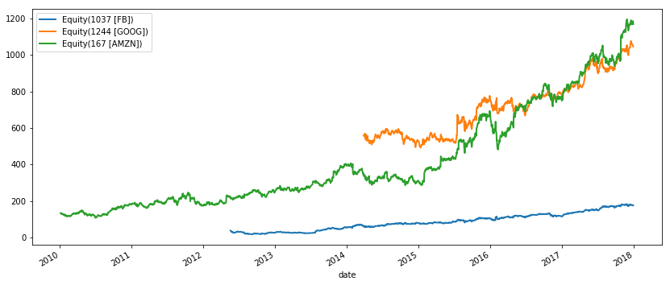

```python
df = pd.read_csv('stock_data.csv')
df.date = pd.to_datetime(df.date)
df.set_index('date').groupby('asset').price.plot(lw=2, legend=True, figsize=(14, 6))
```

### Simple moving average strategy

The following code example illustrates a [Dual Moving Average Cross-Over Strategy](https://zipline.ml4trading.io/beginner-tutorial.html#access-to-previous-prices-using-history) to demonstrate Zipline in action:

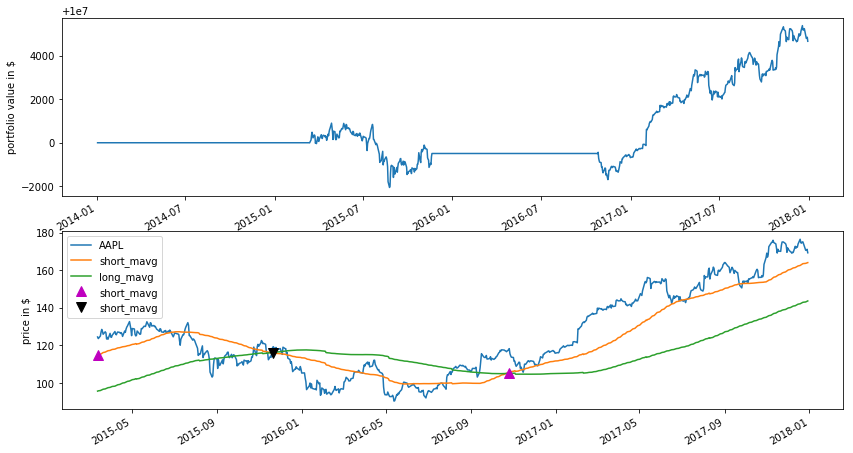

|  | AAPL | algo_volatility | algorithm_period_return | alpha | benchmark_period_return | benchmark_volatility | beta | capital_used | ending_cash | ending_exposure | ... | short_mavg | short_value | shorts_count | sortino | starting_cash | starting_exposure | starting_value | trading_days | transactions | treasury_period_return |
| --- | --- | --- | --- | --- | --- | --- | --- | --- | --- | --- | --- | --- | --- | --- | --- | --- | --- | --- | --- | --- | --- |
| 2014-01-02 21:00:00+00:00 | NaN | NaN | 0.000000 | NaN | 0.002012 | NaN | NaN | 0.0 | 1.000000e+07 | 0.0 | ... | NaN | 0.0 | 0 | NaN | 1.000000e+07 | 0.0 | 0.0 | 1 | [] | 0.0 |
| 2014-01-03 21:00:00+00:00 | NaN | 0.000000 | 0.000000 | NaN | 0.004029 | 0.000000 | NaN | 0.0 | 1.000000e+07 | 0.0 | ... | NaN | 0.0 | 0 | NaN | 1.000000e+07 | 0.0 | 0.0 | 2 | [] | 0.0 |
| 2014-01-06 21:00:00+00:00 | NaN | 0.000000 | 0.000000 | NaN | 0.006049 | 0.000000 | NaN | 0.0 | 1.000000e+07 | 0.0 | ... | NaN | 0.0 | 0 | NaN | 1.000000e+07 | 0.0 | 0.0 | 3 | [] | 0.0 |
| 2014-01-07 21:00:00+00:00 | NaN | 0.000000 | 0.000000 | NaN | 0.008073 | 0.000000 | NaN | 0.0 | 1.000000e+07 | 0.0 | ... | NaN | 0.0 | 0 | NaN | 1.000000e+07 | 0.0 | 0.0 | 4 | [] | 0.0 |
| 2014-01-08 21:00:00+00:00 | NaN | 0.000000 | 0.000000 | NaN | 0.010102 | 0.000000 | NaN | 0.0 | 1.000000e+07 | 0.0 | ... | NaN | 0.0 | 0 | NaN | 1.000000e+07 | 0.0 | 0.0 | 5 | [] | 0.0 |
| 2014-01-09 21:00:00+00:00 | NaN | 0.000000 | 0.000000 | NaN | 0.012134 | 0.000000 | NaN | 0.0 | 1.000000e+07 | 0.0 | ... | NaN | 0.0 | 0 | NaN | 1.000000e+07 | 0.0 | 0.0 | 6 | [] | 0.0 |
| 2014-01-10 21:00:00+00:00 | NaN | 0.000000 | 0.000000 | NaN | 0.014171 | 0.000000 | NaN | 0.0 | 1.000000e+07 | 0.0 | ... | NaN | 0.0 | 0 | NaN | 1.000000e+07 | 0.0 | 0.0 | 7 | [] | 0.0 |
| 2014-01-13 21:00:00+00:00 | NaN | 0.000000 | 0.000000 | NaN | 0.016212 | 0.000000 | NaN | 0.0 | 1.000000e+07 | 0.0 | ... | NaN | 0.0 | 0 | NaN | 1.000000e+07 | 0.0 | 0.0 | 8 | [] | 0.0 |
| 2014-01-14 21:00:00+00:00 | NaN | 0.000000 | 0.000000 | NaN | 0.018257 | 0.000000 | NaN | 0.0 | 1.000000e+07 | 0.0 | ... | NaN | 0.0 | 0 | NaN | 1.000000e+07 | 0.0 | 0.0 | 9 | [] | 0.0 |
| 2014-01-15 21:00:00+00:00 | NaN | 0.000000 | 0.000000 | NaN | 0.020306 | 0.000000 | NaN | 0.0 | 1.000000e+07 | 0.0 | ... | NaN | 0.0 | 0 | NaN | 1.000000e+07 | 0.0 | 0.0 | 10 | [] | 0.0 |
| 2014-01-16 21:00:00+00:00 | NaN | 0.000000 | 0.000000 | NaN | 0.022359 | 0.000000 | NaN | 0.0 | 1.000000e+07 | 0.0 | ... | NaN | 0.0 | 0 | NaN | 1.000000e+07 | 0.0 | 0.0 | 11 | [] | 0.0 |
| 2014-01-17 21:00:00+00:00 | NaN | 0.000000 | 0.000000 | NaN | 0.024416 | 0.000000 | NaN | 0.0 | 1.000000e+07 | 0.0 | ... | NaN | 0.0 | 0 | NaN | 1.000000e+07 | 0.0 | 0.0 | 12 | [] | 0.0 |
| 2014-01-21 21:00:00+00:00 | NaN | 0.000000 | 0.000000 | NaN | 0.026478 | 0.000000 | NaN | 0.0 | 1.000000e+07 | 0.0 | ... | NaN | 0.0 | 0 | NaN | 1.000000e+07 | 0.0 | 0.0 | 13 | [] | 0.0 |
| 2014-01-22 21:00:00+00:00 | NaN | 0.000000 | 0.000000 | NaN | 0.028543 | 0.000000 | NaN | 0.0 | 1.000000e+07 | 0.0 | ... | NaN | 0.0 | 0 | NaN | 1.000000e+07 | 0.0 | 0.0 | 14 | [] | 0.0 |
| 2014-01-23 21:00:00+00:00 | NaN | 0.000000 | 0.000000 | NaN | 0.030613 | 0.000000 | NaN | 0.0 | 1.000000e+07 | 0.0 | ... | NaN | 0.0 | 0 | NaN | 1.000000e+07 | 0.0 | 0.0 | 15 | [] | 0.0 |
| 2014-01-24 21:00:00+00:00 | NaN | 0.000000 | 0.000000 | NaN | 0.032687 | 0.000000 | NaN | 0.0 | 1.000000e+07 | 0.0 | ... | NaN | 0.0 | 0 | NaN | 1.000000e+07 | 0.0 | 0.0 | 16 | [] | 0.0 |
| 2014-01-27 21:00:00+00:00 | NaN | 0.000000 | 0.000000 | NaN | 0.034765 | 0.000000 | NaN | 0.0 | 1.000000e+07 | 0.0 | ... | NaN | 0.0 | 0 | NaN | 1.000000e+07 | 0.0 | 0.0 | 17 | [] | 0.0 |
| 2014-01-28 21:00:00+00:00 | NaN | 0.000000 | 0.000000 | NaN | 0.036847 | 0.000000 | NaN | 0.0 | 1.000000e+07 | 0.0 | ... | NaN | 0.0 | 0 | NaN | 1.000000e+07 | 0.0 | 0.0 | 18 | [] | 0.0 |
| 2014-01-29 21:00:00+00:00 | NaN | 0.000000 | 0.000000 | NaN | 0.038933 | 0.000000 | NaN | 0.0 | 1.000000e+07 | 0.0 | ... | NaN | 0.0 | 0 | NaN | 1.000000e+07 | 0.0 | 0.0 | 19 | [] | 0.0 |
| 2014-01-30 21:00:00+00:00 | NaN | 0.000000 | 0.000000 | NaN | 0.041024 | 0.000000 | NaN | 0.0 | 1.000000e+07 | 0.0 | ... | NaN | 0.0 | 0 | NaN | 1.000000e+07 | 0.0 | 0.0 | 20 | [] | 0.0 |
| 2014-01-31 21:00:00+00:00 | NaN | 0.000000 | 0.000000 | NaN | 0.043119 | 0.000000 | NaN | 0.0 | 1.000000e+07 | 0.0 | ... | NaN | 0.0 | 0 | NaN | 1.000000e+07 | 0.0 | 0.0 | 21 | [] | 0.0 |
| 2014-02-03 21:00:00+00:00 | NaN | 0.000000 | 0.000000 | NaN | 0.045218 | 0.000000 | NaN | 0.0 | 1.000000e+07 | 0.0 | ... | NaN | 0.0 | 0 | NaN | 1.000000e+07 | 0.0 | 0.0 | 22 | [] | 0.0 |
| 2014-02-04 21:00:00+00:00 | NaN | 0.000000 | 0.000000 | NaN | 0.047321 | 0.000000 | NaN | 0.0 | 1.000000e+07 | 0.0 | ... | NaN | 0.0 | 0 | NaN | 1.000000e+07 | 0.0 | 0.0 | 23 | [] | 0.0 |
| 2014-02-05 21:00:00+00:00 | NaN | 0.000000 | 0.000000 | NaN | 0.049429 | 0.000000 | NaN | 0.0 | 1.000000e+07 | 0.0 | ... | NaN | 0.0 | 0 | NaN | 1.000000e+07 | 0.0 | 0.0 | 24 | [] | 0.0 |
| 2014-02-06 21:00:00+00:00 | NaN | 0.000000 | 0.000000 | NaN | 0.051540 | 0.000000 | NaN | 0.0 | 1.000000e+07 | 0.0 | ... | NaN | 0.0 | 0 | NaN | 1.000000e+07 | 0.0 | 0.0 | 25 | [] | 0.0 |
| 2014-02-07 21:00:00+00:00 | NaN | 0.000000 | 0.000000 | NaN | 0.053656 | 0.000000 | NaN | 0.0 | 1.000000e+07 | 0.0 | ... | NaN | 0.0 | 0 | NaN | 1.000000e+07 | 0.0 | 0.0 | 26 | [] | 0.0 |
| 2014-02-10 21:00:00+00:00 | NaN | 0.000000 | 0.000000 | NaN | 0.055776 | 0.000000 | NaN | 0.0 | 1.000000e+07 | 0.0 | ... | NaN | 0.0 | 0 | NaN | 1.000000e+07 | 0.0 | 0.0 | 27 | [] | 0.0 |
| 2014-02-11 21:00:00+00:00 | NaN | 0.000000 | 0.000000 | NaN | 0.057901 | 0.000000 | NaN | 0.0 | 1.000000e+07 | 0.0 | ... | NaN | 0.0 | 0 | NaN | 1.000000e+07 | 0.0 | 0.0 | 28 | [] | 0.0 |
| 2014-02-12 21:00:00+00:00 | NaN | 0.000000 | 0.000000 | NaN | 0.060030 | 0.000000 | NaN | 0.0 | 1.000000e+07 | 0.0 | ... | NaN | 0.0 | 0 | NaN | 1.000000e+07 | 0.0 | 0.0 | 29 | [] | 0.0 |
| 2014-02-13 21:00:00+00:00 | NaN | 0.000000 | 0.000000 | NaN | 0.062163 | 0.000000 | NaN | 0.0 | 1.000000e+07 | 0.0 | ... | NaN | 0.0 | 0 | NaN | 1.000000e+07 | 0.0 | 0.0 | 30 | [] | 0.0 |
| ... | ... | ... | ... | ... | ... | ... | ... | ... | ... | ... | ... | ... | ... | ... | ... | ... | ... | ... | ... | ... | ... |
| 2017-11-16 21:00:00+00:00 | 171.100 | 0.000190 | 0.000485 | -0.000017 | 2.517134 | 0.074234 | 0.000434 | 0.0 | 9.987736e+06 | 17110.0 | ... | 157.284790 | 0.0 | 0 | 0.965627 | 9.987736e+06 | 16908.0 | 16908.0 | 978 | [] | 0.0 |
| 2017-11-17 21:00:00+00:00 | 170.150 | 0.000190 | 0.000475 | -0.000020 | 2.507897 | 0.074223 | 0.000436 | 0.0 | 9.987736e+06 | 17015.0 | ... | 157.533690 | 0.0 | 0 | 0.945562 | 9.987736e+06 | 17110.0 | 17110.0 | 979 | [] | 0.0 |
| 2017-11-20 21:00:00+00:00 | 169.980 | 0.000189 | 0.000473 | -0.000020 | 2.512373 | 0.074185 | 0.000436 | 0.0 | 9.987736e+06 | 16998.0 | ... | 157.802310 | 0.0 | 0 | 0.941678 | 9.987736e+06 | 17015.0 | 17015.0 | 980 | [] | 0.0 |
| 2017-11-21 21:00:00+00:00 | 173.140 | 0.000190 | 0.000505 | -0.000015 | 2.535347 | 0.074195 | 0.000443 | 0.0 | 9.987736e+06 | 17314.0 | ... | 158.099140 | 0.0 | 0 | 1.004004 | 9.987736e+06 | 16998.0 | 16998.0 | 981 | [] | 0.0 |
| 2017-11-22 21:00:00+00:00 | 174.960 | 0.000190 | 0.000523 | -0.000010 | 2.532695 | 0.074164 | 0.000441 | 0.0 | 9.987736e+06 | 17496.0 | ... | 158.419350 | 0.0 | 0 | 1.039646 | 9.987736e+06 | 17314.0 | 17314.0 | 982 | [] | 0.0 |
| 2017-11-24 18:00:00+00:00 | 174.970 | 0.000190 | 0.000523 | -0.000010 | 2.539959 | 0.074128 | 0.000441 | 0.0 | 9.987736e+06 | 17497.0 | ... | 158.733790 | 0.0 | 0 | 1.039316 | 9.987736e+06 | 17496.0 | 17496.0 | 983 | [] | 0.0 |
| 2017-11-27 21:00:00+00:00 | 174.090 | 0.000190 | 0.000514 | -0.000012 | 2.538598 | 0.074095 | 0.000441 | 0.0 | 9.987736e+06 | 17409.0 | ... | 159.052970 | 0.0 | 0 | 1.020718 | 9.987736e+06 | 17497.0 | 17497.0 | 984 | [] | 0.0 |
| 2017-11-28 21:00:00+00:00 | 173.070 | 0.000190 | 0.000504 | -0.000014 | 2.573448 | 0.074183 | 0.000436 | 0.0 | 9.987736e+06 | 17307.0 | ... | 159.347510 | 0.0 | 0 | 0.999183 | 9.987736e+06 | 17409.0 | 17409.0 | 985 | [] | 0.0 |
| 2017-11-29 21:00:00+00:00 | 169.480 | 0.000191 | 0.000468 | -0.000024 | 2.572129 | 0.074151 | 0.000438 | 0.0 | 9.987736e+06 | 16948.0 | ... | 159.597380 | 0.0 | 0 | 0.918573 | 9.987736e+06 | 17307.0 | 17307.0 | 986 | [] | 0.0 |
| 2017-11-30 21:00:00+00:00 | 171.850 | 0.000191 | 0.000492 | -0.000021 | 2.601388 | 0.074195 | 0.000445 | 0.0 | 9.987736e+06 | 17185.0 | ... | 159.866270 | 0.0 | 0 | 0.964547 | 9.987736e+06 | 16948.0 | 16948.0 | 987 | [] | 0.0 |
| 2017-12-01 21:00:00+00:00 | 171.050 | 0.000191 | 0.000484 | -0.000023 | 2.594097 | 0.074176 | 0.000446 | 0.0 | 9.987736e+06 | 17105.0 | ... | 160.125070 | 0.0 | 0 | 0.947936 | 9.987736e+06 | 17185.0 | 17185.0 | 988 | [] | 0.0 |
| 2017-12-04 21:00:00+00:00 | 169.800 | 0.000191 | 0.000472 | -0.000027 | 2.590315 | 0.074148 | 0.000447 | 0.0 | 9.987736e+06 | 16980.0 | ... | 160.351150 | 0.0 | 0 | 0.921919 | 9.987736e+06 | 17105.0 | 17105.0 | 989 | [] | 0.0 |
| 2017-12-05 21:00:00+00:00 | 169.640 | 0.000191 | 0.000470 | -0.000027 | 2.576890 | 0.074154 | 0.000447 | 0.0 | 9.987736e+06 | 16964.0 | ... | 160.562980 | 0.0 | 0 | 0.918310 | 9.987736e+06 | 16980.0 | 16980.0 | 990 | [] | 0.0 |
| 2017-12-06 21:00:00+00:00 | 169.010 | 0.000191 | 0.000464 | -0.000029 | 2.576482 | 0.074120 | 0.000448 | 0.0 | 9.987736e+06 | 16901.0 | ... | 160.763330 | 0.0 | 0 | 0.905278 | 9.987736e+06 | 16964.0 | 16964.0 | 991 | [] | 0.0 |
| 2017-12-07 21:00:00+00:00 | 169.452 | 0.000191 | 0.000468 | -0.000028 | 2.586969 | 0.074088 | 0.000448 | 0.0 | 9.987736e+06 | 16945.2 | ... | 160.962920 | 0.0 | 0 | 0.913444 | 9.987736e+06 | 16901.0 | 16901.0 | 992 | [] | 0.0 |
| 2017-12-08 21:00:00+00:00 | 169.370 | 0.000191 | 0.000467 | -0.000028 | 2.606720 | 0.074080 | 0.000447 | 0.0 | 9.987736e+06 | 16937.0 | ... | 161.152330 | 0.0 | 0 | 0.911380 | 9.987736e+06 | 16945.2 | 16945.2 | 993 | [] | 0.0 |
| 2017-12-11 21:00:00+00:00 | 172.670 | 0.000191 | 0.000500 | -0.000021 | 2.618269 | 0.074049 | 0.000450 | 0.0 | 9.987736e+06 | 17267.0 | ... | 161.381510 | 0.0 | 0 | 0.975229 | 9.987736e+06 | 16937.0 | 16937.0 | 994 | [] | 0.0 |
| 2017-12-12 21:00:00+00:00 | 171.700 | 0.000191 | 0.000491 | -0.000024 | 2.623873 | 0.074012 | 0.000450 | 0.0 | 9.987736e+06 | 17170.0 | ... | 161.601690 | 0.0 | 0 | 0.955174 | 9.987736e+06 | 17267.0 | 17267.0 | 995 | [] | 0.0 |
| 2017-12-13 21:00:00+00:00 | 172.270 | 0.000191 | 0.000496 | -0.000022 | 2.622159 | 0.073980 | 0.000449 | 0.0 | 9.987736e+06 | 17227.0 | ... | 161.809440 | 0.0 | 0 | 0.965782 | 9.987736e+06 | 17170.0 | 17170.0 | 996 | [] | 0.0 |
| 2017-12-14 21:00:00+00:00 | 172.220 | 0.000191 | 0.000496 | -0.000022 | 2.607414 | 0.073993 | 0.000449 | 0.0 | 9.987736e+06 | 17222.0 | ... | 162.010210 | 0.0 | 0 | 0.964324 | 9.987736e+06 | 17227.0 | 17227.0 | 997 | [] | 0.0 |
| 2017-12-15 21:00:00+00:00 | 173.870 | 0.000191 | 0.000512 | -0.000020 | 2.639788 | 0.074056 | 0.000454 | 0.0 | 9.987736e+06 | 17387.0 | ... | 162.220310 | 0.0 | 0 | 0.995906 | 9.987736e+06 | 17222.0 | 17222.0 | 998 | [] | 0.0 |
| 2017-12-18 21:00:00+00:00 | 176.420 | 0.000191 | 0.000538 | -0.000016 | 2.659308 | 0.074047 | 0.000458 | 0.0 | 9.987736e+06 | 17642.0 | ... | 162.484800 | 0.0 | 0 | 1.044938 | 9.987736e+06 | 17387.0 | 17387.0 | 999 | [] | 0.0 |
| 2017-12-19 21:00:00+00:00 | 174.540 | 0.000192 | 0.000519 | -0.000021 | 2.647487 | 0.074045 | 0.000461 | 0.0 | 9.987736e+06 | 17454.0 | ... | 162.741050 | 0.0 | 0 | 1.005265 | 9.987736e+06 | 17642.0 | 17642.0 | 1000 | [] | 0.0 |
| 2017-12-20 21:00:00+00:00 | 174.350 | 0.000191 | 0.000517 | -0.000021 | 2.644467 | 0.074016 | 0.000462 | 0.0 | 9.987736e+06 | 17435.0 | ... | 163.001870 | 0.0 | 0 | 1.001059 | 9.987736e+06 | 17454.0 | 17454.0 | 1001 | [] | 0.0 |
| 2017-12-21 21:00:00+00:00 | 175.010 | 0.000191 | 0.000524 | -0.000020 | 2.651704 | 0.073979 | 0.000462 | 0.0 | 9.987736e+06 | 17501.0 | ... | 163.257340 | 0.0 | 0 | 1.013325 | 9.987736e+06 | 17435.0 | 17435.0 | 1002 | [] | 0.0 |
| 2017-12-22 21:00:00+00:00 | 175.010 | 0.000191 | 0.000524 | -0.000020 | 2.650031 | 0.073948 | 0.000462 | 0.0 | 9.987736e+06 | 17501.0 | ... | 163.442190 | 0.0 | 0 | 1.012820 | 9.987736e+06 | 17501.0 | 17501.0 | 1003 | [] | 0.0 |
| 2017-12-26 21:00:00+00:00 | 170.570 | 0.000193 | 0.000479 | -0.000033 | 2.646167 | 0.073920 | 0.000467 | 0.0 | 9.987736e+06 | 17057.0 | ... | 163.598280 | 0.0 | 0 | 0.913225 | 9.987736e+06 | 17501.0 | 17501.0 | 1004 | [] | 0.0 |
| 2017-12-27 21:00:00+00:00 | 170.600 | 0.000192 | 0.000480 | -0.000033 | 2.649051 | 0.073884 | 0.000467 | 0.0 | 9.987736e+06 | 17060.0 | ... | 163.746503 | 0.0 | 0 | 0.913342 | 9.987736e+06 | 17057.0 | 17057.0 | 1005 | [] | 0.0 |
| 2017-12-28 21:00:00+00:00 | 171.080 | 0.000192 | 0.000484 | -0.000032 | 2.655744 | 0.073848 | 0.000467 | 0.0 | 9.987736e+06 | 17108.0 | ... | 163.899520 | 0.0 | 0 | 0.922021 | 9.987736e+06 | 17060.0 | 17060.0 | 1006 | [] | 0.0 |
| 2017-12-29 21:00:00+00:00 | 169.230 | 0.000193 | 0.000466 | -0.000037 | 2.636795 | 0.073882 | 0.000471 | 0.0 | 9.987736e+06 | 16923.0 | ... | 163.997280 | 0.0 | 0 | 0.884195 | 9.987736e+06 | 17108.0 | 17108.0 | 1007 | [] | 0.0 |

1007 rows × 40 columns

```python
%%zipline --start 2014-1-1 --end 2018-1-1 --no-benchmark -o dma.pickle
from zipline.api import order_target, record, symbol
import matplotlib.pyplot as plt

def initialize(context):
    context.i = 0
    context.asset = symbol('AAPL')


def handle_data(context, data):
    # Skip first 300 days to get full windows
    context.i += 1
    if context.i < 300:
        return

    # Compute averages
    # data.history() has to be called with the same params
    # from above and returns a pandas dataframe.
    short_mavg = data.history(context.asset, 'price', bar_count=100, frequency="1d").mean()
    long_mavg = data.history(context.asset, 'price', bar_count=300, frequency="1d").mean()

    # Trading logic
    if short_mavg > long_mavg:
        # order_target orders as many shares as needed to
        # achieve the desired number of shares.
        order_target(context.asset, 100)
    elif short_mavg < long_mavg:
        order_target(context.asset, 0)

    # Save values for later inspection
    record(AAPL=data.current(context.asset, 'price'),
           short_mavg=short_mavg,
           long_mavg=long_mavg)


def analyze(context, perf):
    fig, (ax1, ax2) = plt.subplots(nrows=2,figsize=(14, 8))
    perf.portfolio_value.plot(ax=ax1)
    ax1.set_ylabel('portfolio value in $')

    perf['AAPL'].plot(ax=ax2)
    perf[['short_mavg', 'long_mavg']].plot(ax=ax2)

    perf_trans = perf.loc[[t != [] for t in perf.transactions]]
    buys = perf_trans.loc[[t[0]['amount'] > 0 for t in perf_trans.transactions]]
    sells = perf_trans.loc[
        [t[0]['amount'] < 0 for t in perf_trans.transactions]]
    ax2.plot(buys.index, perf.short_mavg.loc[buys.index],
             '^', markersize=10, color='m')
    ax2.plot(sells.index, perf.short_mavg.loc[sells.index],
             'v', markersize=10, color='k')
    ax2.set_ylabel('price in $')
    plt.legend(loc=0)
    plt.show()
```